# Trabajar con tablas o marcos de datos con R

Última actualización:

15 de mayo de 2026

# Preparación

En esta práctica trabajaremos en el entorno de R, con los paquetes siguientes: `dplyr`, `kableExtra` y `jsonlite`. Para descargar algunos datos de ejemplo, usaremos los programas `datasets` y `dataformat` (O’Leary et al. 2024), que pueden descargarse en [este enlace](https://www.ncbi.nlm.nih.gov/datasets/docs/v2/command-line-tools/download-and-install/).

# Objetivos

1. Conocer el uso de `datasets` y `dataformat`.
2. Ver algún ejemplo de archivo en formato JSON.
3. Manipular marcos de datos sin usar hojas de cálculo.

# Datos

Supón que tenemos interés en descargar un genoma de referencia de cualquier especie del género *Trypanosoma*, así como su anotación funcional, en formato [GFF3](https://github.com/The-Sequence-Ontology/Specifications/blob/master/gff3.md).

Veamos primero de qué opciones disponemos:

```bash
cd "$(p=$(pwd); while [ ! -f "$p"/*.Rproj ] && [ "$p" != "/" ]; do p=$(dirname "$p"); done; echo "$p")"

if [ ! -e  ./data/Practica_04/trypanosoma_annotated.txt ]; then
   ./data/Practica_04/datasets summary genome taxon Trypanosoma --annotated --as-json-lines | \
   ./data/Practica_04/dataformat tsv genome --fields \
      accession,organism-name,assminfo-release-date,assminfo-level,assmstats-atgc-count,annotinfo-featcount-gene-total,assminfo-type,assminfo-status > ./data/Practica_04/trypanosoma_annotated.txt
fi
```

La línea larga que sigue a `--fields` especifica qué información sobre los genomas queremos ver en la tabla. Para saber qué campos se pueden seleccionar, puedes ejecutar la orden `dataformat tsv genome --help`. Veamos esa tabla en el informe HTML en un formato adecuado.

```r
PBioinfo <- system("curr=$PWD; while [ \"$curr\" != \"/\" ] && [ -z \"$(ls \"$curr\"/*.Rproj 2>/dev/null)\" ]; do curr=$(dirname \"$curr\"); done; echo \"$curr\"", intern = TRUE)

setwd(PBioinfo)

library('kableExtra')
genomas <- read.table('./data/Practica_04/trypanosoma_annotated.txt',
                      header = TRUE, sep = '\t')
kable(genomas) %>% kable_styling()
```

[output not shown]

**NotaDesafío**

1. ¿Qué diferencia hay entre las líneas 7 y 8 de la tabla anterior?
2. Busca una función de R que te permita identificar las líneas repetidas en un marco de datos.

**NotaRespuestas**

1. La única diferencia visible es el nombre (uno comienza por GCA y el otro por GCF), pero esta diferencia nos indica que la calidad de ambos archivos es distinta. Los genomas marcados como GCA son archivos que han sido subidos a la base de datos tal cual lo subieron los investigadores que lo secuenciaron; de forma que no han pasado por un proceso de validación, procesado y estandarización por ningún organismo de calidad. Por otro lado, los genomas marcados por GCF son genomas que sí han pasado por este proceso de estandarización por el equipo de RefSeq del NCBI, garantizando una calidad correcta.
2. Si tan solo queremos identificar las lineas repetidas, R tiene una función que se llama `duplicated`:

```r
esta_duplicado <- duplicated(genomas)
print(esta_duplicado)
```

```
 [1] FALSE FALSE FALSE FALSE FALSE FALSE FALSE FALSE FALSE FALSE FALSE FALSE
[13] FALSE FALSE FALSE FALSE FALSE FALSE FALSE FALSE FALSE FALSE FALSE FALSE
[25] FALSE FALSE FALSE FALSE FALSE FALSE FALSE FALSE FALSE FALSE FALSE
```

Esto sirve para líneas exactamente idénticas; pero de forma habitual no existen estas líneas porque tienen un identificador diferente. Por tanto, vamos a buscar lineas idénticas ignorando el identificador:

```r
esta_duplicado_sinID <- duplicated(genomas[, -1])
print(esta_duplicado_sinID)
```

```
 [1] FALSE FALSE FALSE FALSE FALSE FALSE FALSE  TRUE FALSE FALSE  TRUE FALSE
[13] FALSE FALSE FALSE FALSE FALSE FALSE FALSE FALSE FALSE FALSE FALSE FALSE
[25]  TRUE FALSE FALSE FALSE  TRUE FALSE FALSE  TRUE FALSE FALSE FALSE
```

Y si no solo queremos saber cuales están duplicadas si no que nos interesa que nos diga toda la información de las que están duplicadas:

```r
datos_duplicados_sinID <- genomas[esta_duplicado_sinID,]
print(datos_duplicados_sinID)
```

```
   Assembly.Accession         Organism.Name Assembly.Release.Date
8     GCA_003719485.1 Trypanosoma conorhini            2018-11-08
11    GCA_000209065.1     Trypanosoma cruzi            2005-08-02
25    GCA_000691245.1     Trypanosoma grayi            2014-05-15
29    GCA_003719475.1   Trypanosoma rangeli            2018-11-08
32    GCA_002087225.1  Trypanosoma theileri            2017-04-12
   Assembly.Level Assembly.Stats.ATGC.Count Annotation.Count.Gene.Total
8        Scaffold                  21137671                       10321
11       Scaffold                  89612356                       25210
25       Scaffold                  20791447                       10676
29       Scaffold                  20977846                       10589
32       Scaffold                  25688935                       11312
        Assembly.Type Assembly.Status
8             haploid         current
11 unresolved-diploid         current
25            haploid         current
29            haploid         current
32            haploid         current
```

Solo pone los GCA porque en la tabla siempre aparecen segundos; pero están copiados de un GCF correspondiente.

Gemini me ha mencionado también un paquete llamado `janitor` que al parecer funciona muy bien, usando la función ``get_dupes(genomas,2)`.

# Ordenar una tabla

La función `order()` produce los índices ordenados de los elementos de un vector.

Consulta su ayuda y experimenta con ella. Vamos a usar esta función para ordenar las filas del marco de datos `genomas` por fecha, que es la tercera columna, llamada `Assembly.Release.Date`.

```r
# Observa que asignamos el resultado del ordenamiento al mismo objeto que
# estamos ordenando, para guardar el resultado sin tener que generar otro objeto.
library(grDevices)
library(kableExtra)

genomas <- genomas[order(genomas$Assembly.Release.Date), ]

kable(genomas) %>% kable_styling()
```

Casualmente, la fecha estaba en formato “%Y-%m-%d”, en el que el orden alfabético coincide con el orden temporal. Al crear `genomas`, `read.table()` había interpretado la tercera columna como texto. Para que las fechas sean entendidas como tales, podemos usar la función `as.Date()`:

```r
genomas$Assembly.Release.Date <- as.Date(genomas$Assembly.Release.Date,
                                         '%Y-%m-%d')
```

Una vez convertida en “fecha”, la columna “Assembly.Release.Date” puede usarse correctamente, por ejemplo, como eje de abscisas en una gráfica:

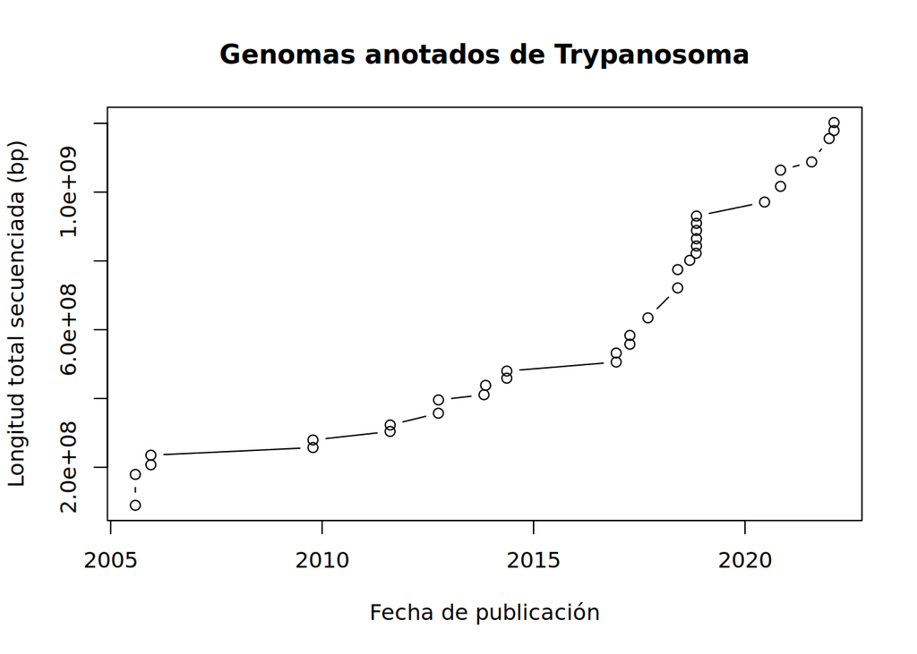

```r
# Aquí usamos "cumsum()" para obtener la suma acumulada del número de bases
# secuenciadas.
plot(x = genomas$Assembly.Release.Date,
     y = cumsum(genomas$Assembly.Stats.ATGC.Count),
     type = 'b',
     xlab = 'Fecha de publicación',
     ylab = 'Longitud total secuenciada (bp)',
     main = 'Genomas anotados de Trypanosoma')
```

# Archivos JSON y GFF

Habiendo visto las opciones, decidimos descargar el genoma y la anotación funcional de una de ellas, por ejemplo GCA_022059095.1.

```bash
cd "$(p=$(pwd); while [ ! -f "$p"/*.Rproj ] && [ "$p" != "/" ]; do p=$(dirname "$p"); done; echo "$p")"

if [ ! -e ./data/Practica_04/ncbi_dataset/data/GCA_022059095.1/genomic.gff ]; then
   if [ ! -e ./data/Practica_04/ncbi_dataset.zip ]; then
      ./data/17-02-2026/datasets download genome accession GCA_022059095.1 --include genome,gff3 --filename ./data/Practica_04/ncbi_dataset.zip
   fi
   unzip ./data/Practica_04/ncbi_dataset.zip -d ./data/Practica_04/
fi
```

En la carpeta `ncbi_dataset/data` encontrarás un archivo en formato JSON con información sobre los datos descargados, y un archivo en formato “jsonlines”. El formato “jsonlines” es una versión de JSON en la que cada registro ocupa una sola línea. Esto dificulta la visualización, pero agiliza el análisis de los datos en la línea de órdenes. Para ver mejor el contenido del archivo con la extensión `jsonl`, podríamos utilizar el programa [`jq`](https://jqlang.org/), o bien utilizar la función `prettify()` del paquete `jsonlite` de R:

```r
PBioinfo <- system("curr=$PWD; while [ \"$curr\" != \"/\" ] && [ -z \"$(ls \"$curr\"/*.Rproj 2>/dev/null)\" ]; do curr=$(dirname \"$curr\"); done; echo \"$curr\"", intern = TRUE)

setwd(PBioinfo)

library('jsonlite')
prettify(readLines('./data/Practica_04/ncbi_dataset/data/assembly_data_report.jsonl'))
```

Volviendo a lo que nos interesa, vamos a cargar en un marco de datos de una sesión de R la anotación funcional del genoma escogido. Aunque existen funciones específicas para leer archivos GFF, usaremos la función básica `read.table()`, con alguna precaución.

```r
# Como no tiene cabecera, le damos los nombres de las columnas:
PBioinfo <- system("curr=$PWD; while [ \"$curr\" != \"/\" ] && [ -z \"$(ls \"$curr\"/*.Rproj 2>/dev/null)\" ]; do curr=$(dirname \"$curr\"); done; echo \"$curr\"", intern = TRUE)

setwd(PBioinfo)

gff <- read.table('./data/Practica_04/ncbi_dataset/data/GCA_022059095.1/genomic.gff', sep = '\t',
                  col.names = c('seqid', 'source', 'type', 'start', 'end',
                                'score', 'strand', 'phase', 'attributes'),
                  quote = '')
```

Al leer el archivo GFF con `read.table()`, debemos especificar que el separador de columnas es el tabulador y que no hay texto entrecomillado en el archivo.

Esto último se consigue con la opción `quote = ''`, y sirve para evitar que todo lo que se encuentre entre dos apóstrofes (*’*) se considere parte de un mismo campo de información, aunque sean cientos de líneas.

Para comprobar que el archivo ha sido leído completo y sin errores, conviene revisar las dimensiones del marco de datos (`dim(gff)`) o incluso visualizar el principio (`head(gff)`) y el final (`tail(gff)`) del objeto, que es demasiado grande para mostrarlo en pantalla completo.

## Seleccionar filas y columnas

En el objeto `gff` hay 5 valores diferentes de la variable `type`: “CDS”, “exon”, “gene”, “mRNA” y “region”. Puedes comprobarlo con `unique(gff$type)`, o con `table(gff$type)`. Podemos separar la tabla en cinco marcos de datos, que correspondan a esos cinco tipos de anotación funcional.

```r
# Usamos un vector booleano como índice de las filas.
# En las tablas nuevas, no necesitamos la tercera columna
# y la eliminamos con el "-3".

gene   <- gff[gff$type == 'gene',   -3]
mrna   <- gff[gff$type == 'mRNA',   -3]
exon   <- gff[gff$type == 'exon',   -3]
cds    <- gff[gff$type == 'CDS',    -3]
region <- gff[gff$type == 'region', -3]

# Alinear las órdenes nos ayuda a detectar posibles errores
```

**NotaDesafío**

Identifica en cada uno de estos marcos de datos qué columnas son invariables. Esdecir, las columnas que tienen el mismo valor en todas las líneas. Y elimina esas columnas.

**NotaSolución**

Para identificar que columnas son invariables, existen varios métodos, pero voy a usar uno que utiliza el paquete `dplyr`. Este paquete tiene una funnción de limpieza de tablas con un único comando:

```r
library(dplyr)

exon_limpio <- exon %>%
  select(where(~ n_distinct(.) > 1))
```

Lo repetimos con el resto de las tablas:

```r
mrna_limpio <- mrna %>%
  select(where(~ n_distinct(.) > 1))

gene_limpio <- gene %>%
  select(where(~ n_distinct(.) > 1))

region_limpio <- region %>%
  select(where(~ n_distinct(.) > 1))

cds_limpio <- cds %>%
  select(where(~ n_distinct(.) > 1))
```

Hay que tener cuidado pprque esto puede eliminar columnas que si que nos van a servir en análisis posteriores. Por ejemplo, al hacer esta limpieza del tipo “region”, eliminamos la columna de start, puesto que siempre comienza por 1. Esto impide elaborar un resumen correcto como se nos pide en apartados futuros.

## Agrupar, operar y resumir

Habiendo separado los diferentes tipos de anotaciones, ahora resulta fácil obtener estadísticas de cada uno. Podemos querer una tabla que nos diga para cada tipo de anotación, cuántos elementos de ese tipo hay en el genoma, qué longitud media tienen y qué desviación estándar. Hay diferentes maneras de conseguirlo. La más rudimentaria implicaría obtener cada estadística individualmente y después juntarlas en una nueva tabla. Por ejemplo, para regiones codificantes (“CDS”):

```r
cds$longitud <- cds$end - cds$start + 1
resumen <- data.frame(
   tipo       = 'CDS',
   número     = nrow(cds),
   long.Media = mean(cds$longitud),
   long.SD    = sd(cds$longitud)
)
```

**NotaDesafío**

¿Sabrías completar el marco de datos `resumen` con los datos de los otros cuatro tipos de anotación funcional?

**NotaSolución**

El paquete `dplyr` también tiene una función para añadir filas de forma muy simple. La idea es crear nuevos datasets con los datos de todas nuestras anotaciones y después juntarlos todos en el resumen. Para ello, hacemos:

```r
mrna$longitud <- mrna$end - mrna$start + 1
mrna_resumen <- data.frame(
   tipo       = 'mRNA',
   número     = nrow(mrna),
   long.Media = mean(mrna$longitud),
   long.SD    = sd(mrna$longitud)
)

region$longitud <- region$end - region$start + 1
region_resumen <- data.frame(
   tipo       = 'region',
   número     = nrow(region),
   long.Media = mean(region$longitud),
   long.SD    = sd(region$longitud)
)

exon$longitud <- exon$end - exon$start + 1
exon_resumen <- data.frame(
   tipo       = 'exon',
   número     = nrow(exon),
   long.Media = mean(exon$longitud),
   long.SD    = sd(exon$longitud)
)

gene$longitud <- gene$end - gene$start + 1
gene_resumen <- data.frame(
   tipo       = 'gene',
   número     = nrow(gene),
   long.Media = mean(gene$longitud),
   long.SD    = sd(gene$longitud)
)

resumen <- bind_rows(resumen, mrna_resumen, exon_resumen, gene_resumen, region_resumen)
```

Este tipo de operación es bastante habitual, y se puede hacer sin necesidad de crear marcos de datos parciales como he hecho yo. La función `split()` divide las líneas de un marco de datos en tantos marcos de datos como valores diferentes (*niveles*) haya en el *factor* que usemos para definir los grupos. El resultado es un solo objeto: una *lista* de marcos de datos:

```r
# Esto es una lista de marcos de datos:
porTipo <- split(gff, gff$type)

# Estas funciones nos permiten inspeccionar algunas características
# del nuevo objeto:
class(porTipo)
```

```
[1] "list"
```

```r
length(porTipo)
```

```
[1] 5
```

```r
names(porTipo)
```

```
[1] "CDS"    "exon"   "gene"   "mRNA"   "region"
```

```r
sapply(porTipo, class)
```

```
         CDS         exon         gene         mRNA       region
"data.frame" "data.frame" "data.frame" "data.frame" "data.frame"
```

```r
sapply(porTipo, nrow)
```

```
   CDS   exon   gene   mRNA region
 11304  11304   9768  10057     64
```

La función `sapply()`, toma al menos dos argumentos: una lista (o vector) y una función. Devuelve un vector (si es posible) con los resultados de aplicar la función a cada elemento de la lista. Con esto, el resumen que queríamos se puede obtener así:

```r
# Primero calculamos las longitudes de todas las anotaciones en gff:
gff$longitud <- gff$end - gff$start + 1

# Volvemos a separar las filas por tipo, ahora que tenemos las longitudes:
porTipo <- split(gff, gff$type)

resumen <- data.frame(
   tipo = names(porTipo),
   número = sapply(porTipo, nrow),
   long.Media = sapply(porTipo, function(x) mean(x$longitud)),
   long.SD    = sapply(porTipo, function(x)   sd(x$longitud))
)

# Aprovechamos para mostrar nombres de columnas más legibles:
kable(resumen,
      col.names = c('Tipo', 'Número', 'Longitud Media',
                    'Desviación estándar'),
      row.names = FALSE) %>%
   kable_styling(full_width = FALSE)
```

| Tipo | Número | Longitud Media | Desviación estándar |
| --- | --- | --- | --- |
| CDS | 11304 | 1358.661 | 1377.899 |
| exon | 11304 | 1358.661 | 1377.899 |
| gene | 9768 | 1553.822 | 1466.322 |
| mRNA | 10057 | 1549.331 | 1466.240 |
| region | 64 | 364120.594 | 314801.149 |

Las operaciones de agrupar y resumir se pueden hacer también con funciones del paquete `dplyr`, que forma parte de un conjunto de paquetes diseñados para funcionar armoniosamente entre ellos. Son los paquetes del [`tidyverse`](https://tidyverse.org/), muy populares en ciencia de datos. Casi se pueden considerar un dialecto de R. Las funciones (o *verbos*) más interesantes de `dplyr` son `group_by()` y `summarise()`.

```r
library('dplyr')
# Observa el uso de "tuberías" ("%>%"):
resumen <- gff %>% group_by(type) %>% summarise(
   número     = n(),
   Long.Media = mean(longitud),
   Long.SD    = sd(longitud)
)
kable(resumen,
      col.names = c('Tipo', 'Número', 'Longitud Media',
                    'Desviación estándar'),
      row.names = FALSE) %>%
   kable_styling(full_width = FALSE)
```

| Tipo | Número | Longitud Media | Desviación estándar |
| --- | --- | --- | --- |
| CDS | 11304 | 1358.661 | 1377.899 |
| exon | 11304 | 1358.661 | 1377.899 |
| gene | 9768 | 1553.822 | 1466.322 |
| mRNA | 10057 | 1549.331 | 1466.240 |
| region | 64 | 364120.594 | 314801.149 |

**NotaDesafío**

Crea una tabla con el número total de genes en cada cromosoma. ¿Puedes contar cuántos hay codificados en cada sentido (“strand”) y en cada cromosoma?

**NotaSolución**

Para poder hacer esto, lo primero que tenemos que saber es como han marcado en nuestro dataset que un gen pertenece a un cromosoma o a otro. Lo más habitual es que lo hayan hecho identificandoles diferentes id, lo que nos permite filtrar por seqid para saber cuantos genes pertenecen a cada uno:

```r
filtrado_genes <- gff %>% group_by(seqid) %>% summarise(
  cantidad_genes = sum(type == "gene"),
  genes_pos = sum(type == "gene" & strand == "+"),
  genes_neg = sum(type == "gene" & strand == "-")
)
```

# Comparar o cruzar datos

Imagina que un estudio señala los cromosomas siguientes como posiblemente asociados a la resistencia a un fármaco. Quieres saber qué genes hay en estos cinco cromosomas:

- JAJSEB010000048.1
- JAJSEB010000012.1
- JAJSEB010000020.1
- JAJSEB010000016.1
- JAJSEB010000033.1

Antes hemos usado el operador lógico `==` para crear un vector booleano con el que seleccionar algunas líneas. En este caso usaremos el operador `%in%`, que compara conjuntos o vectores de caracteres:

```r
candidatos <- c("JAJSEB010000048.1",
                "JAJSEB010000012.1",
                "JAJSEB010000020.1",
                "JAJSEB010000016.1",
                "JAJSEB010000033.1")
interesantes <- gff[gff$seqid %in% candidatos, ]
dim(interesantes)
```

```
[1] 4792   10
```

**NotaDesafío**

¿Puedes limitar la selección a anotaciones de tipo “gene”?

**NotaSolución**

Lo vamos a hacer de forma similar a como lo hemos hecho antes:

```r
interesantes_genes <- interesantes[interesantes$type == 'gene', -3]
```

El estudio avanza y reduce el tamaño de las regiones candidatas, así que ahora necesitas identificar los genes presentes en exactamente las regiones siguientes:

- JAJSEB010000048.1:184638-253478
- JAJSEB010000012.1:133444-348860
- JAJSEB010000020.1:73393-149614
- JAJSEB010000016.1:161247-272009
- JAJSEB010000033.1:123135-170687

Aunque existen programas específicos para comparar segmentos cromosómicos ([bedtools](https://github.com/arq5x/bedtools2)), continuaremos practicando con marcos de datos de R. Ahora ya no podemos usar `%in%`, porque de cada cromosoma queremos unos segmentos diferentes. Una estrategia es crear cinco filtros booleanos, y después combinarlos con la operación lógica “o”, es decir `|`. En cada filtro seleccionaremos las anotaciones que estén completamente contenidas en el intervalo indicado.

```r
f1 <- gff$seqid == 'JAJSEB010000048.1' & gff$start >= 184638 & gff$end <= 253478
f2 <- gff$seqid == 'JAJSEB010000012.1' & gff$start >= 133444 & gff$end <= 348860
f3 <- gff$seqid == 'JAJSEB010000020.1' & gff$start >= 73393  & gff$end <= 149614
f4 <- gff$seqid == 'JAJSEB010000016.1' & gff$start >= 161247 & gff$end <= 272009
f5 <- gff$seqid == 'JAJSEB010000033.1' & gff$start >= 123135 & gff$end <= 170687

f <- f1 | f2 | f3 | f4 | f5

interesantes <- gff[f, ]
nrow(interesantes)
```

```
[1] 920
```

**NotaDesafío**

¿Puedes cambiar los filtros para que incluyan también genes *parcialmente* contenidos en los intervalos indicados?

**NotaSolución**

El resultado quedaría tal que:

```r
f1 <- gff$seqid == 'JAJSEB010000048.1' & ! (gff$start <= 184638 & gff$end <= 184638) & ! (gff$start >= 253478 & gff$end >= 253478)
f2 <- gff$seqid == 'JAJSEB010000012.1' & ! (gff$start <= 133444 & gff$end <= 133444) & ! (gff$start >= 348860 & gff$end >= 348860)
f3 <- gff$seqid == 'JAJSEB010000020.1' & ! (gff$start <= 73393 & gff$end <= 73393) & ! (gff$start >= 149614  & gff$end >= 149614)
f4 <- gff$seqid == 'JAJSEB010000016.1' & ! (gff$start <= 161247 & gff$end <= 161247) & ! (gff$start >= 272009 & gff$end >= 272009)
f5 <- gff$seqid == 'JAJSEB010000033.1' & ! (gff$start <= 123135 & gff$end <= 123135) & ! (gff$start >= 170687 & gff$end >= 170687)

f <- f1 | f2 | f3 | f4 | f5

interesantes <- gff[f, ]
nrow(interesantes)
```

```
[1] 952
```

Hemos pasado de 920 a 952 entidades (recordemos que no hemos filtrado genes a partir de este script)

# Las llaves y la función `match()`

En las bases de datos relacionales se llama *llave* a la columna o al conjunto de columnas cuyos valores identifican unívocamente cada línea de la tabla. En los marcos de datos de R, las líneas pueden tener nombre, el cual puede usarse como *llave* o índice para seleccionar líneas. Pero el uso del nombre de las líneas no es recomendable. Lo más práctico es que en cualquier tabla haya una columna cuyos valores no puedan repetirse. Esto ayuda a evitar duplicidades, mantener la integridad de la tabla y relacionar unas tablas con otras.

**Nota**

¿Cuál es la *llave* en un archivo GFF?

**Nota**

En un archivo GFF, la llave será la columna *attributes*, dónde se indica un ID específico para cada dato además de información adicional.

El código siguiente descarga la tabla de genomas de *Trypanosoma* ensamblados a nivel de cromosoma, de la [European Nucleotide Archive](https://www.ebi.ac.uk/ena/)

```r
# Aprenderemos esta sintaxis en el próximo tema:
portal <- 'https://www.ebi.ac.uk/ena/portal/api/search?'
result <- 'result=assembly&'
query  <- 'query=tax_tree(5690)&'
fields <- 'fields=accession%2Cversion%2Cscientific_name%2Cbase_count%2Clast_updated%2Cassembly_level'
URL <- paste0(portal, result, query, fields)
genomas.ena <- read.table(URL, header = TRUE, sep = '\t', quote = '', na.strings = '')
```

Tanto el nuevo marco de datos `genomas.ena`, como el que habíamos creado antes con datos de NCBI, `genomas`, tienen una columna de valores únicos: “accession” o “Assembly.Accession”. Para los registros comunes entre las dos tablas, podemos transferir información de una a otra. Por ejemplo, vamos a añadir a la tabla `genomas` la fecha de última modificación del ensamblaje, que encontramos en `genomas.ena`. Para asegurarnos de que a cada ensamblaje le asignamos el valor correcto, usaremos la función `match()`.

En `genomas`, “Assembly.Accession” incluye un sufijo que indica el número de versión del ensamblaje. Este sufijo no está presente en `genomas.ena$accession`.

Para hacer comparables ambas tablas, quitaremos el sufijo de la primera tabla.

```r
# Este es un uso avanzado de `sapply()` y `strsplit()`:
genomas$acc <- sapply(
   strsplit(genomas$Assembly.Accession, '.', fixed = TRUE),
   '[', 1
)

genomas$last_updated <- genomas.ena[match(genomas$acc,
                                          genomas.ena$accession),
                                    'last_updated']
```

**NotaDesafíos**

1. ¿Cómo comprobarías que al eliminar el sufijo de la versión, `genomas$acc` sigue siendo una *llave* de la tabla `genomas`?
2. Siguiendo el mismo esquema añade a `genomas` el “base_count” y compáralo con el “Assembly.Stats.ATGC.Count”. Si observas alguna diferencia, intenta explicarla.

## Apéndice

En los archivos GFF, la columna `attributes` es una lista de parejas de valores “clave = valor”, separadas por punto y coma (“;”). Habiendo creado antes un marco de datos para cada tipo de anotación (genes, CDS, etc.), es de suponer que todas las líneas de un marco de datos tendrán el mismo conjunto de parejas “clave = valor”. Aquí se muestra una manera de extraer esta información y convertirla en columnas adicionales de un marco de datos.

Veamos el primer valor de `attributes` en el marco de datos `gene`:

```r
gene[1, 'attributes']
```

```
[1] "ID=gene-LSM04_009031;Name=LSM04_009031;gbkey=Gene;gene_biotype=protein_coding;locus_tag=LSM04_009031"
```

La función `strsplit()` en R divide una cadena de caracteres en partes delimitadas por algún carácter o expresión regular. En este caso, queremos dividir esa cadena por los puntos y coma:

```r
strsplit(gene[1, 'attributes'], ';')
```

```
[[1]]
[1] "ID=gene-LSM04_009031"        "Name=LSM04_009031"
[3] "gbkey=Gene"                  "gene_biotype=protein_coding"
[5] "locus_tag=LSM04_009031"
```

`strsplit()` ha dividido la cadena de caracteres original en una *lista* que contiene un único vector de cinco cadenas de caracteres. El motivo de generar una lista en lugar de un simple vector es que `strsplit()` puede actuar simultáneamente sobre todas las cadenas de caracteres de un vector, y necesita repartir el resultado en diferentes vectores:

```r
strsplit(gene[1:3, 'attributes'], ';')
```

```
[[1]]
[1] "ID=gene-LSM04_009031"        "Name=LSM04_009031"
[3] "gbkey=Gene"                  "gene_biotype=protein_coding"
[5] "locus_tag=LSM04_009031"

[[2]]
[1] "ID=gene-LSM04_007573"        "Name=LSM04_007573"
[3] "gbkey=Gene"                  "gene_biotype=protein_coding"
[5] "locus_tag=LSM04_007573"

[[3]]
[1] "ID=gene-LSM04_000706"        "Name=LSM04_000706"
[3] "gbkey=Gene"                  "gene_biotype=protein_coding"
[5] "locus_tag=LSM04_000706"
```

Podemos guardar la lista de los vectores de los atributos de cada gen en un nuevo objeto, para continuar operando sobre el después:

```r
atributos <- strsplit(gene[ , 'attributes'], ';')

# Veamos los 6 primeros elementos:
head(atributos)
```

```
[[1]]
[1] "ID=gene-LSM04_009031"        "Name=LSM04_009031"
[3] "gbkey=Gene"                  "gene_biotype=protein_coding"
[5] "locus_tag=LSM04_009031"

[[2]]
[1] "ID=gene-LSM04_007573"        "Name=LSM04_007573"
[3] "gbkey=Gene"                  "gene_biotype=protein_coding"
[5] "locus_tag=LSM04_007573"

[[3]]
[1] "ID=gene-LSM04_000706"        "Name=LSM04_000706"
[3] "gbkey=Gene"                  "gene_biotype=protein_coding"
[5] "locus_tag=LSM04_000706"

[[4]]
[1] "ID=gene-LSM04_000559"        "Name=LSM04_000559"
[3] "gbkey=Gene"                  "gene_biotype=protein_coding"
[5] "locus_tag=LSM04_000559"

[[5]]
[1] "ID=gene-LSM04_006454"        "Name=LSM04_006454"
[3] "gbkey=Gene"                  "gene_biotype=protein_coding"
[5] "locus_tag=LSM04_006454"

[[6]]
[1] "ID=gene-LSM04_009090"        "Name=LSM04_009090"
[3] "gbkey=Gene"                  "gene_biotype=protein_coding"
[5] "locus_tag=LSM04_009090"
```

```r
# Y la longitud total de la lista:
length(atributos)
```

```
[1] 9768
```

Una vez tenemos una lista de los atributos de cada gen, podemos usar funciones de la familia `lapply()` para operar en paralelo sobre todos sus elementos. Examina la ayuda de `lapply()` para familiarizarte con estas funciones. A continuación, la usaremos para separar la clave del valor en todos los atributos de todos los genes. Además asignaremos la clave como nombre del valor correspondiente (en R, los elementos de un vector pueden tener nombre).

```r
atributos2 <- lapply(
   atributos,
   # Definimos una función para aplicarla a cada elemento de "atributos".
   function(x) {
      # "x" es un vector de atributos de un solo gen
      lista <- strsplit(x, '=')
      # "lista" es una lista de vectores de 2 componentes, clave y valor
      valores <- sapply(lista, '[', 2)
      names(valores) <- sapply(lista, '[', 1)
      return(valores)
   }
)
head(atributos2)
```

```
[[1]]
                 ID                Name               gbkey        gene_biotype
"gene-LSM04_009031"      "LSM04_009031"              "Gene"    "protein_coding"
          locus_tag
     "LSM04_009031"

[[2]]
                 ID                Name               gbkey        gene_biotype
"gene-LSM04_007573"      "LSM04_007573"              "Gene"    "protein_coding"
          locus_tag
     "LSM04_007573"

[[3]]
                 ID                Name               gbkey        gene_biotype
"gene-LSM04_000706"      "LSM04_000706"              "Gene"    "protein_coding"
          locus_tag
     "LSM04_000706"

[[4]]
                 ID                Name               gbkey        gene_biotype
"gene-LSM04_000559"      "LSM04_000559"              "Gene"    "protein_coding"
          locus_tag
     "LSM04_000559"

[[5]]
                 ID                Name               gbkey        gene_biotype
"gene-LSM04_006454"      "LSM04_006454"              "Gene"    "protein_coding"
          locus_tag
     "LSM04_006454"

[[6]]
                 ID                Name               gbkey        gene_biotype
"gene-LSM04_009090"      "LSM04_009090"              "Gene"    "protein_coding"
          locus_tag
     "LSM04_009090"
```

El orden de los atributos se ha mantenido idéntico al orden de sus correspondientes genes. Por eso podemos ahora añadir las columnas de atributos que queramos al marco de datos `gene`:

```r
gene$ID           <- sapply(atributos2, '[', 'ID')
gene$Name         <- sapply(atributos2, '[', 'Name')
gene$gene_biotype <- sapply(atributos2, '[', 'gene_biotype')
gene$locus_tag    <- sapply(atributos2, '[', 'locus_tag')

f <- names(gene) != 'attributes'
kable(gene[1:15, f]) %>% kable_styling()
```

|  | seqid | source | start | end | score | strand | phase | longitud | ID | Name | gene_biotype | locus_tag |
| --- | --- | --- | --- | --- | --- | --- | --- | --- | --- | --- | --- | --- |
| 2 | JAJSEB010000004.1 | Genbank | 246 | 935 | . | - | . | 690 | gene-LSM04_009031 | LSM04_009031 | protein_coding | LSM04_009031 |
| 8 | JAJSEB010000004.1 | Genbank | 2204 | 2776 | . | + | . | 573 | gene-LSM04_007573 | LSM04_007573 | protein_coding | LSM04_007573 |
| 12 | JAJSEB010000004.1 | Genbank | 3011 | 3706 | . | + | . | 696 | gene-LSM04_000706 | LSM04_000706 | protein_coding | LSM04_000706 |
| 16 | JAJSEB010000004.1 | Genbank | 4768 | 4986 | . | + | . | 219 | gene-LSM04_000559 | LSM04_000559 | protein_coding | LSM04_000559 |
| 20 | JAJSEB010000004.1 | Genbank | 5540 | 8959 | . | + | . | 3420 | gene-LSM04_006454 | LSM04_006454 | protein_coding | LSM04_006454 |
| 24 | JAJSEB010000004.1 | Genbank | 9198 | 9512 | . | + | . | 315 | gene-LSM04_009090 | LSM04_009090 | protein_coding | LSM04_009090 |
| 28 | JAJSEB010000004.1 | Genbank | 9877 | 12936 | . | + | . | 3060 | gene-LSM04_002876 | LSM04_002876 | protein_coding | LSM04_002876 |
| 32 | JAJSEB010000004.1 | Genbank | 13160 | 14620 | . | + | . | 1461 | gene-LSM04_001088 | LSM04_001088 | protein_coding | LSM04_001088 |
| 36 | JAJSEB010000004.1 | Genbank | 14840 | 16024 | . | + | . | 1185 | gene-LSM04_006263 | LSM04_006263 | protein_coding | LSM04_006263 |
| 40 | JAJSEB010000004.1 | Genbank | 16367 | 16935 | . | + | . | 569 | gene-LSM04_007732 | LSM04_007732 | protein_coding | LSM04_007732 |
| 46 | JAJSEB010000004.1 | Genbank | 17016 | 17411 | . | + | . | 396 | gene-LSM04_006531 | LSM04_006531 | protein_coding | LSM04_006531 |
| 52 | JAJSEB010000004.1 | Genbank | 17834 | 19039 | . | + | . | 1206 | gene-LSM04_007917 | LSM04_007917 | protein_coding | LSM04_007917 |
| 56 | JAJSEB010000004.1 | Genbank | 19420 | 20313 | . | + | . | 894 | gene-LSM04_009571 | LSM04_009571 | protein_coding | LSM04_009571 |
| 60 | JAJSEB010000004.1 | Genbank | 20625 | 21875 | . | + | . | 1251 | gene-LSM04_003035 | LSM04_003035 | protein_coding | LSM04_003035 |
| 64 | JAJSEB010000004.1 | Genbank | 22111 | 22929 | . | + | . | 819 | gene-LSM04_003619 | LSM04_003619 | protein_coding | LSM04_003619 |

## Bibliografía

O’Leary, N. A., E. Cox, J. B. Holmes, W. R. Anderson, R. Falk, V. Hem, M. T. N. Tsuchiya, et al. 2024. «Exploring and retrieving sequence and metadata for species across the tree of life with NCBI datasets». *Scientific Data* 11: 732. https://doi.org/10.1038/s41597-024-03571-y.